# Inteligencia Artificial - Laboratorio 1 -

## Task 1 - Regresión Lineal

### Responda a cada de las siguientes preguntas de forma clara y lo más completamente posible.

#### 1. Considera un modelo de regresión lineal con dos características, X₁ y X₂, y sus pesos correspondientes w₁ y w₂. Si el modelo predice una salida y mediante la ecuación y = 2w₁X₁ + 3w₂X₂ + 1, ¿cuál es la interpretación del coeficiente 3w₂ en el contexto del modelo?

- los coeficientes asociados a las características representan su contribución al modelo, para la característica X₂ y el coeficiente 3w₂ nos indica que cualquier valor del peso w₂ cambia en 3 unidades constantes, por lo que el modelo se ve más afectado por este peso w₂ que por el peso w₁.

#### 2. Explica el concepto de multicolinealidad en el contexto de la regresión lineal. ¿Cómo afecta la multicolinealidad a la interpretación de los coeficientes de regresión individuales?

- la multicolinealidad ocurre cuando dos o más variables de características están altamente correlacionadas entre sí. Si existe una fuerte relación lineal entre estas variables predictoras, puede afectar negativamente la interpretación de los coeficientes de regresión individuales debido a que no se podrá determinar con exactitud la contribución de cada variable por separado.

## Task 2 - Clasificación de Sitios de Phishing Regresión Logística y KNN

#### Como bien se sabe, los sitios web de phishing siguen siendo de las formas más efectivas para los cibercriminales para robar información. Por ello, aprender a identificar de forma proactiva aquellos sitios sospechosos para poder bloquearlos es una tarea importante. Bajo este contexto, se le ha solicitado que cree modelos para la identificación de sitios. Para ello:

- Usará el dataset proporcionado en Kaggle en el siguiente enlace
  - Recuerden que pueden descargar el código directamente con llaves generadas desde Kaggle o bien pueden ingresar al enlace y descargar el archivo como usualmente lo hace con cualquier otro documento
- La especificación de las columnas la encuentran en el siguiente enlace
  - Las columnas se especifican a partir de la página 6
- Deben hacer una breve exploración con los datos. Esto implica, pero no está limitado a:
  - Hacer encoding de las variables que se necesiten
  - Revisar si el dataset está balanceado, caso no estarlo, aplicar alguna técnica para balancearlo lo más y mejor posible
  - Escalar las variables si considera necesario
  - Selección de variables
- Recuerden hacer el split para training, testing y si consideran necesario para validationx
  - 80% training
  - 20% testing
    - 10% validation si lo necesitan
- Recuerde definir de forma clara y razonada (es decir, diga el por qué de su elección) de una métrica de desempeño principal

##### Análisis de exploración

```r
dt <- read.csv("dataset_phishing.csv")
dim(dt)
```

```
## [1] 11430    89
```

```r
dt <- subset(dt, select = c(length_url, length_hostname, ratio_digits_url, phish_hints, nb_subdomains, status))
status <- data.frame(table(dt$status))
names(status) <- c("status", "observaciones")
kable(status, "html") %>%
  kable_styling(bootstrap_options = "striped", full_width = F, font_size = 16)
```

| status | observaciones |
| --- | --- |
| legitimate | 5715 |
| phishing | 5715 |

```r
str(dt)
```

```
## 'data.frame':    11430 obs. of  6 variables:
##  $ length_url      : int  37 77 126 18 55 32 19 81 42 104 ...
##  $ length_hostname : int  19 23 50 11 15 24 12 27 34 10 ...
##  $ ratio_digits_url: num  0 0.221 0.151 0 0 ...
##  $ phish_hints     : int  0 0 0 0 0 0 0 0 0 1 ...
##  $ nb_subdomains   : int  3 1 3 2 2 3 2 2 2 1 ...
##  $ status          : chr  "legitimate" "phishing" "phishing" "legitimate" ...
```

```r
summary(dt)
```

```
##    length_url      length_hostname  ratio_digits_url   phish_hints
##  Min.   :  12.00   Min.   :  4.00   Min.   :0.00000   Min.   : 0.0000
##  1st Qu.:  33.00   1st Qu.: 15.00   1st Qu.:0.00000   1st Qu.: 0.0000
##  Median :  47.00   Median : 19.00   Median :0.00000   Median : 0.0000
##  Mean   :  61.13   Mean   : 21.09   Mean   :0.05314   Mean   : 0.3277
##  3rd Qu.:  71.00   3rd Qu.: 24.00   3rd Qu.:0.07937   3rd Qu.: 0.0000
##  Max.   :1641.00   Max.   :214.00   Max.   :0.72388   Max.   :10.0000
##  nb_subdomains      status
##  Min.   :1.000   Length:11430
##  1st Qu.:2.000   Class :character
##  Median :2.000   Mode  :character
##  Mean   :2.232
##  3rd Qu.:3.000
##  Max.   :3.000
```

```r
kable(colSums(sapply(dt, is.na)))
```

|  | x |
| --- | --- |
| length_url | 0 |
| length_hostname | 0 |
| ratio_digits_url | 0 |
| phish_hints | 0 |
| nb_subdomains | 0 |
| status | 0 |

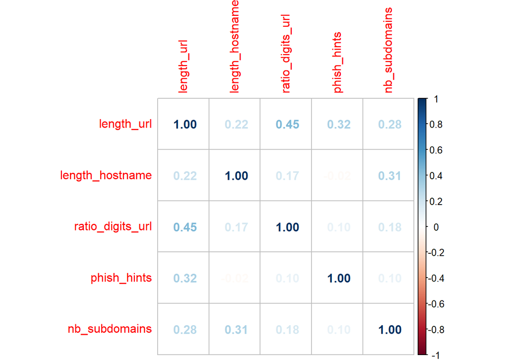

```r
dt$real <- ifelse(dt$status=='phishing', 1, 0)
sample <- sample(c(TRUE, FALSE), nrow(dt), replace=TRUE, prob=c(0.8,0.2))
train  <- dt[sample, ]
test   <- dt[!sample, ]


cors <- subset(dt, select = -c(status, real))
correlations <- cor(cors)
cols <- correlations[,colSums(abs(correlations), na.rm = TRUE) == 1] %>% colnames()
correlations <- correlations[,colSums(abs(correlations), na.rm = TRUE) != 1]
correlations <- correlations[!row.names(correlations) %in% cols,]
corrplot(correlations, method="number")
```

## Task 2.1 - Regresión Logística

### Implemente desde cero el algoritmo de Regresión Logística. Para ello considere lo siguiente

- Recuerde implementar el algoritmo de gradiente descendente, tomando en cuenta parámetros como el learning rate y épocas
- Utilice el dataset proporcionado para mostrar el funcionamiento de su algoritmo
- Provea una métrica de desempeño, justificando su elección
- Grafique los grupos encontrados
  - Puede usar solamente dos variables para mostrarlos en un plano cartesiano
- Mencione, como comentario las consideraciones extras que tuvo que tomar en cuenta durante la realización de su implementación Para este task no usen librerías, sino implementen el algoritmo por ustedes mismos. Además, evite el uso de herramientas de AI generativas (ChatGPT). Luego:
- Repita los pasos para entrenar su modelo, pero ahora usando librerías, y compare los resultados.
- Para esta parte sí puede usar herramientas de AI generativas.
- Responda:
  - ¿Cuál implementación fue mejor? ¿Por qué?

```r
# Función de Regresión Logística
reg_log <- function(X, y, learning_rate, epochs){

  # Inicializar los parámetros
  m <- nrow(X)
  n <- ncol(X)
  w <- matrix(0, n, 1)
  costo <- vector()

  # Función sigmoide
  sigmoid <- function(z) {
    return (1 / (1 + exp(-z)))
  }

  # Función de costo
  cost_function <- function(X, y, w) {
    h <- sigmoid(X %*% w)
    cost <- -(1/m) * sum(y * log(h) + (1 - y) * log(1 - h))
    return(cost)
  }

  # Función gradiente
  for (epoch in 1:epochs) {
    h <- sigmoid(X %*% w)
    gradient <- t(X) %*% (h - y) / m
    w <- w - learning_rate * gradient

    # Mostrar el costo
    if (epoch %% 100 == 0) {
      costo <- rbind(costo, cost_function(X, y, w))
    }
  }
  plot(costo)
  return(w)
}

# Función de predicción
predict_reg_log <- function(X, theta){
  h <- sigmoid(X %*% theta)
  predictions <- ifelse(h >= 0.5, 1, 0)
  return(predictions)
}
```

```r
# Generar datos de entrenamiento
Xi <- as.matrix.data.frame(subset(train, select = -c(status, real)))
yi <- train$real

# Aplicar el modelo
theta <- reg_log(Xi, yi, 0.0001, 100000)
```

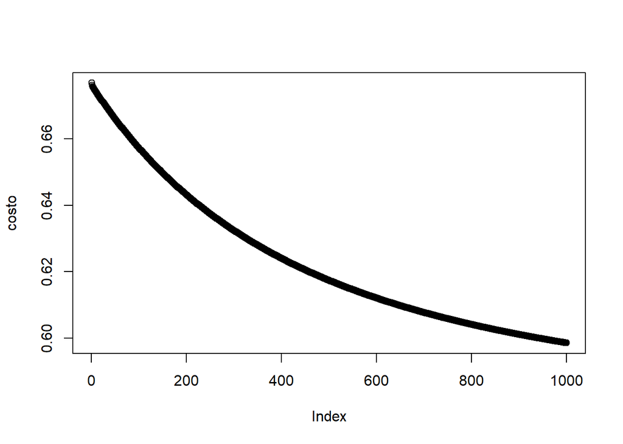

```r
# Generar datos de test
Xf <- as.matrix(subset(test, select = -c(status, real)))
yf <- test$real

# Realizar predicciones
preds <- predict_reg_log(Xf, theta)

# Matriz de confusión
cm <- confusionMatrix(as.factor(yf), as.factor(preds))

Xf <- cbind(as.data.frame(Xf), yf, preds)

cm$table
```

```
##           Reference
## Prediction   0   1
##          0 785 359
##          1 360 732
```

```r
cm$byClass[1]
```

```
## Sensitivity
##   0.6855895
```

```r
cm$byClass[2]
```

```
## Specificity
##   0.6709441
```

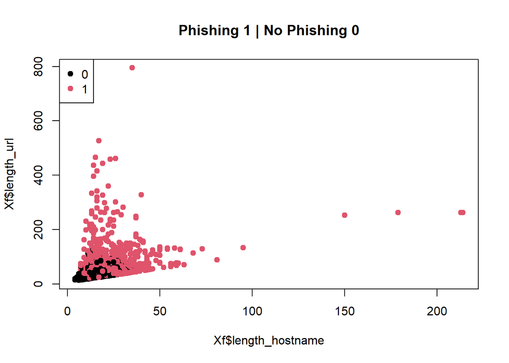

```r
# Plot de grupos
plot(Xf$length_hostname, Xf$length_url,
     main="Phishing 1 | No Phishing 0",
     pch = 19,
     col = factor(Xf$preds))
legend("topleft",
       legend = levels(factor(Xf$preds)),
       pch = 19,
       col = factor(levels(factor(Xf$preds))))
```

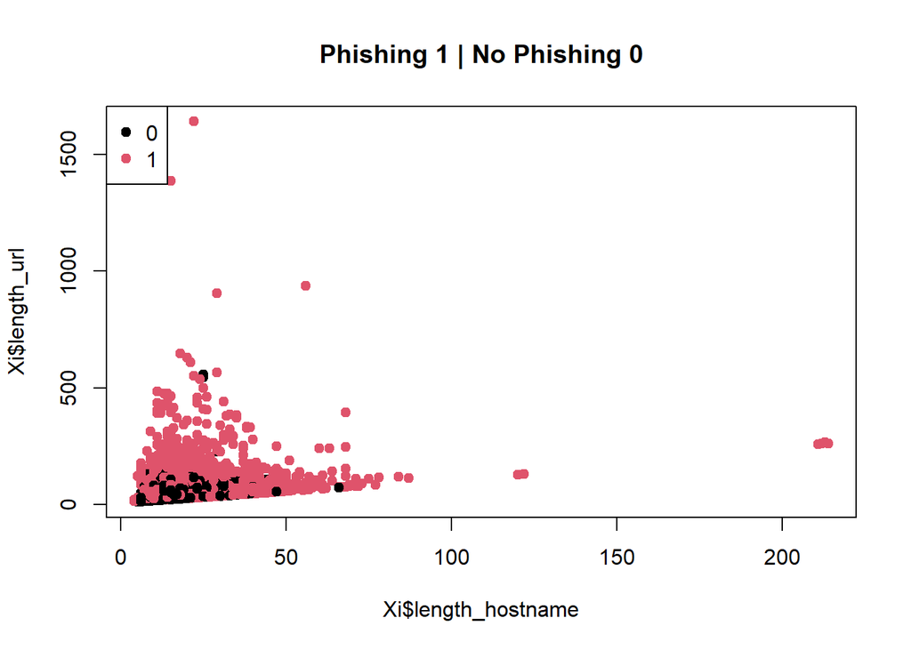

```r
Xi<- as.data.frame(Xi)
Xi$real <- train$real
plot(Xi$length_hostname, Xi$length_url,
     main="Phishing 1 | No Phishing 0",
     pch = 19,
     col = factor(Xi$real))
legend("topleft",
       legend = levels(factor(Xi$real)),
       pch = 19,
       col = factor(levels(factor(Xi$real))))
```

Ahora, se hará la regresión logística con una librería, en este caso glm, provee la generación de este modelo. Realizamos el entrenamiento y prueba, donde nos da un resultado mejor, donde la sensibilidad y especificidad es de 71% y 80% respectivamente. La razón por la cual este modelo obtuvo mejor rendimiento es debido a que es un modelo lineal generalizado, por lo que internamente busca evitar linerealidad en las variables y evitar el overfitting, dando un mejor resultado.

```r
# Generar datos de entrenamiento
Xi <- as.data.frame(subset(train, select = -c(status)))
yi <- test$real
reg_log_glm <- glm(real ~.,family=binomial(link='logit'),data=Xi)

# Generar datos de prueba
Xf <- as.data.frame(subset(test, select = -c(status, real)))
Xf$preds <- ifelse(predict(reg_log_glm,newdata=Xf,type='response') >= 0.5, 1, 0)
Xf$real <- test$real

# Matriz de confusión
cm <- confusionMatrix(as.factor(Xf$real), as.factor(Xf$pred))
cm$table
```

```
##           Reference
## Prediction   0   1
##          0 971 173
##          1 392 700
```

```r
cm$byClass[1]
```

```
## Sensitivity
##   0.7123991
```

```r
cm$byClass[2]
```

```
## Specificity
##   0.8018328
```

## Task 2.2 - K-Nearest Neighbors

### Implemente desde cero el algoritmo de K-Nearest Neighbors. Para ello considere lo siguiente

- La distancia entre puntos debe ser la dada por la forma de la distancia Euclidiana
- Utilice el dataset proporcionado para mostrar el funcionamiento de su algoritmo
- Provea una métrica de desempeño, justificando su elección
- Grafique los grupos encontrados
  - Puede usar solamente dos variables para mostrarlos en un plano cartesiano
- Mencione, como comentario las consideraciones extras que tuvo que tomar en cuenta durante la realización de su implementación Para este task no usen librerías, sino implementen el algoritmo por ustedes mismos. Además, evite el uso de herramientas de AI generativas (ChatGPT). Luego:
- Repita los pasos para entrenar su modelo, pero ahora usando librerías, y compare los resultados.
- Para esta parte sí puede usar herramientas de AI generativas.
- Responda:
  - ¿Cuál implementación fue mejor? ¿Por qué?

Para el siguiente algoritmo, se implementó K-Nearest-Neighbors, el cual mide la distancia de un punto hacia otros y ve sus clases para asignarle a este nuevo punto,dependiendo de cuantos puntos de que clase esten en un área específica. El rendimiento que se obtuvo fue de 68% de sensibilidad y 83% de especificidad. Podemos ver que la especificidad, que tanto predicirá que una página web es phishing y este en lo correcto es mayor a la detección de no phishing y estar en lo correcto. Lo que supera en buena medida al algoritmo de regresión logística.

```r
# Función distancia euclidiana
euclidean <- function(a, b) {
  sqrt(sum((a - b)^2))
}

# Función k-Nearest Neighbors
r_knn <- function(Xf, k, Xi, Y) {

  # Obtener la distancia euclidiana
  dist <- apply(Xi, 1, function(row) euclidean(row, Xf))

  # Obtener las clases mas cercanas
  ids <- order(dist)[1:k]
  classes <- unique(Y)
  count <- numeric(length(classes))

  for (i in seq_along(classes)) {
    count[i] <- sum(classes[i] == Y[ids])
  }

  max_prob_class <- classes[which.max(count)]

  return(max_prob_class)
}

# Función de predicción de knn
pred_knn <- function(Xi, y, Xf, k) {
  predictions <- vector()
  for (i in 1:nrow(Xf)) {
    result <- r_knn(as.numeric(Xf[i, ]), k, Xi, y)
    predictions <- append(predictions, result)
  }
  return(predictions)
}


# Generar datos de entrenamiento
Xi <- as.data.frame(subset(train, select = -c(status, real)))
Yi <- train$real

# Generar datos de prueba
Xf <- as.data.frame(subset(test, select = -c(status, real)))
Yf <- test$real

preds <- pred_knn(Xi, Yi, Xf, 2)
Xf <- cbind(as.data.frame(Xf), Yf, preds)
cm <- confusionMatrix(as.factor(Yf), as.factor(preds))
cm$table
```

```
##           Reference
## Prediction    0    1
##          0 1016  128
##          1  459  633
```

```r
cm$byClass[1]
```

```
## Sensitivity
##   0.6888136
```

```r
cm$byClass[2]
```

```
## Specificity
##   0.8318003
```

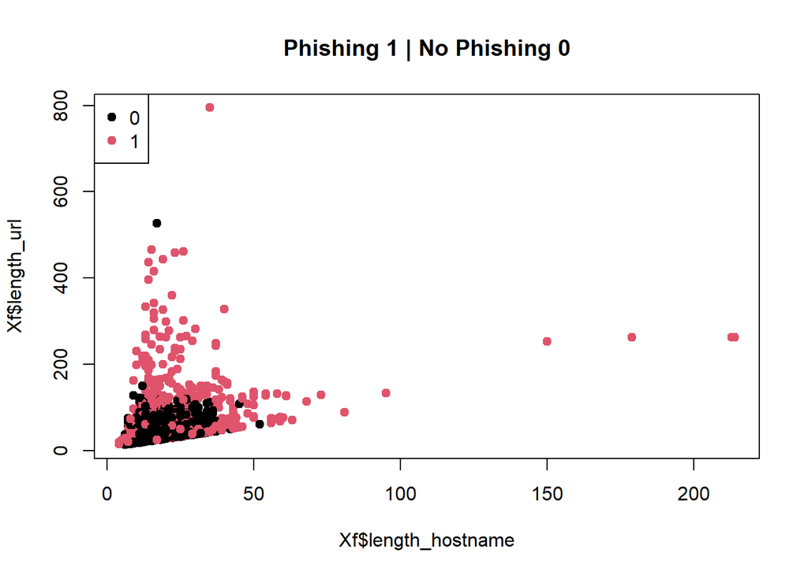

```r
# Plot de grupos
plot(Xf$length_hostname, Xf$length_url,
     main="Phishing 1 | No Phishing 0",
     pch = 19,
     col = factor(Xf$preds))
legend("topleft",
       legend = levels(factor(Xf$preds)),
       pch = 19,
       col = factor(levels(factor(Xf$preds))))
```

Finalmente se aplica el modelo KNN de la librería caret, en donde obtenemos una métrica de rendimiento bastante similar al KNN implementado anteriormente. Esta librería utiliza otra manera de calcular la distancia, lo cual puede hacer que, para este caso en particular y dataset, haya obtenido un resultado distinto pero muy similar al algoritmo implementado.

```r
# Generar datos de entrenamiento
Xi <- as.data.frame(subset(train, select = -c(real)))

# Generar datos de prueba
Xf <- as.data.frame(subset(test, select = -c(real)))

classifier_knn <- train(status~., data=Xi, method="knn")
Xf$prediction <- predict(classifier_knn, Xf)

cm <- confusionMatrix(as.factor(Xf$status), as.factor(Xf$prediction))
cm$table
```

```
##             Reference
## Prediction   legitimate phishing
##   legitimate        964      180
##   phishing          377      715
```

```r
cm$byClass[1]
```

```
## Sensitivity
##   0.7188665
```

```r
cm$byClass[2]
```

```
## Specificity
##   0.7988827
```

### Anexo

#### Repositorio en github

- https://github.com/ivanhez/IALAB1/

### Referencias

- https://www.kaggle.com/datasets/shashwatwork/web-page-phishing-detection-dataset/data
- https://www.analyticsvidhya.com/blog/2022/02/implementing-logistic-regression-from-scratch-using-python/
- https://arxiv.org/pdf/2010.12847.pdf
- https://www.rdocumentation.org/packages/stats/versions/3.6.2/topics/glm
- https://www.datacamp.com/tutorial/logistic-regression-R
- https://rpubs.com/JairoAyala/601703